# Geog533 Lab 9

Complete the following exercises in Chapter 9 (More on Regression) of the textbook pages 286-287.

## Question 1

This is Exercise 7 in Chapter 9 of the Textbook [R].

The following results were obtained from a regression of $n = 14$ housing prices (in dollars) on median family income, size of house, and size of lot:

|  | Sum of squares | df | Mean square | F |
| --- | --- | --- | --- | --- |
| Regression SS: | 4234 | 3 |  |  |
| Residual SS: | 3487 |  |  |  |
| Total SS: |  |  |  |  |

|  | Coefficient (b) | Standard error (sb) | VIF |
| --- | --- | --- | --- |
| Median family income | 1.57 | 0.34 | 1.3 |
| Size of house (sq.ft) | 23.4 | 11.2 | 2.9 |
| Size of lot (sq.ft) | -9.5 | 7.1 | 11.3 |
| Constant | 40,000 | 1000 |  |

### Question 1(a)

Fill in the blanks.

```r
SST<- 4234 + 3487
dft <- 13
col1 <- c("Regression SS:","Residual SS:","Total SS:")
col2 <- c("4234","3487",SST)
col3 <- c("3",dft-3,dft)
col4 <- c(round(4234/3,digits = 2),3487/(dft-3),"")
col5 <- c(round((4234/3)/(3487/(dft-3)),digits = 5),"","")
df <- cbind(col1,col2,col3,col4,col5)
colnames(df) <- c("","Sum of squares","df","Mean square","F")
kable(df)
```

|  | Sum of squares | df | Mean square | F |
| --- | --- | --- | --- | --- |
| Regression SS: | 4234 | 3 | 1411.33 | 4.04741 |
| Residual SS: | 3487 | 10 | 348.7 |  |
| Total SS: | 7721 | 13 |  |  |

### Question 1(b)

What is the value of $r^2$?

```r
R <- 4234/SST
R
```

```
[1] 0.5483746
```

### Question 1(c)

What is the standard error of the estimate?

```r
a <- 3487/(dft-3)
sd.err <- sqrt(a)
sd.err
```

```
[1] 18.67351
```

### Question 1(d)

Test the null hypothesis that $R^2 = 0$ by comparing the $F-statistic$ from the table with its critical value.

```r
f_cri<- qf(0.95,df1 = 3,df2 = 10)
F <- 4.04741
if(F > f_cri)
{
  print('R^2 not equal to 0')
}
```

```
[1] "R^2 not equal to 0"
```

### Question 1(e)

Are the coefficients in the direction you would hypothesize? If not, which coefficients are opposite in sign from what you would expect?

```r
print('The coefficent of size of lot does not fit our expect, the coefficent suppose to be a possitive number')
```

```
[1] "The coefficent of size of lot does not fit our expect, the coefficent suppose to be a possitive number"
```

### Question 1(f)

Find the $t-statistics$ associated with each coefficient, and test the null hypotheses that the coefficients are equal to zero. Use $ = 0.05$, and be sure to give the critical value of $t$.

```r
t_cri<- qt(0.975,df = 13)
if((1.57/0.34) > t_cri)
  print('the coefficients of income is not equal to zero')
```

```
[1] "the coefficients of income is not equal to zero"
```

```r
if((23.4/11.2) < t_cri){
print('the coefficients of Size of house is  equal to zero')}
```

```
[1] "the coefficients of Size of house is  equal to zero"
```

```r
if((-9.5/7.1) > -t_cri)
{print('the coefficients of Size of lot is  equal to zero')}
```

```
[1] "the coefficients of Size of lot is  equal to zero"
```

### Question 1(g)

What do you conclude from the variance inflation factors (VIFs)? What (if any) modifications would you recommend in light of the VIFs?

```r
print('The value named Size of lot is not independent,so i recommend that remove this value')
```

```
[1] "The value named Size of lot is not independent,so i recommend that remove this value"
```

### Question 1(h)

What is the predicted sales price of a house that is 1500 square feet, on a lot 60´×100´, and in a neighborhood where the median family income is $40,000?

```r
price <- 1500*23.4 - (9.5*60*100/144) + 1.57*40000 + 40000
price
```

```
[1] 137504.2
```

## Question 2

This is Exercise 10 in Chapter 9 of the Textbook [R].

### Question 2(a)

Using R and the [Hypothetical UK Housing Prices dataset](http://spatial.binghamton.edu/geog533/data/UK_Housing.csv), construct a regression equation using housing price as the dependent variable, and bedrooms, bathrooms, date built, garage, fireplace, floor area, and whether the home is detached as the independent variables. Investigate the importance of multicollinearity and outliers. Comment on the weaknesses of this specification, and on the results.

```r
url = "http://spatial.binghamton.edu/geog533/data/UK_Housing.csv"
df <- read.csv(url)
m <- lm(df$price~df$bedrooms + df$bathrooms + df$datebuilt + df$garage +df$fireplace + df$floorarea + df$detached)
a <- anova(m)
sst<- sum(a$`Sum Sq`)
r <- a$`Sum Sq`/sst
vif <- 1/(1-r)
rbind(row.names(a),round(vif,digits = 3))
```

```
     [,1]          [,2]           [,3]           [,4]        [,5]           [,6]           [,7]          [,8]
[1,] "df$bedrooms" "df$bathrooms" "df$datebuilt" "df$garage" "df$fireplace" "df$floorarea" "df$detached" "Residuals"
[2,] "1.37"        "1.01"         "1.059"        "1.166"     "1.001"        "1.246"        "1.02"        "1.435"
```

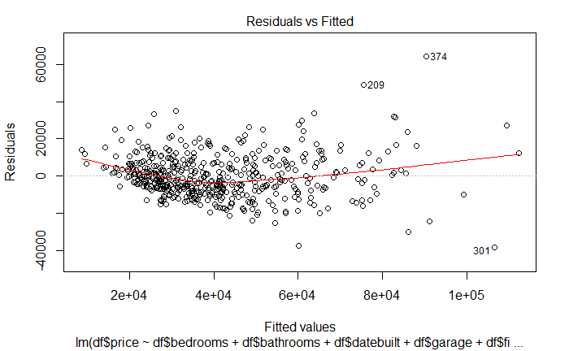

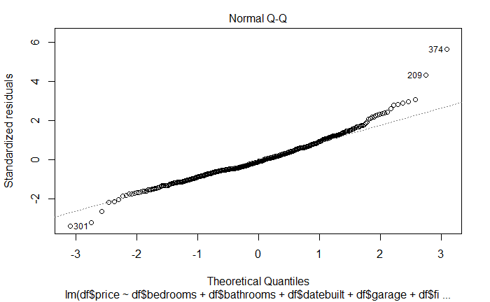

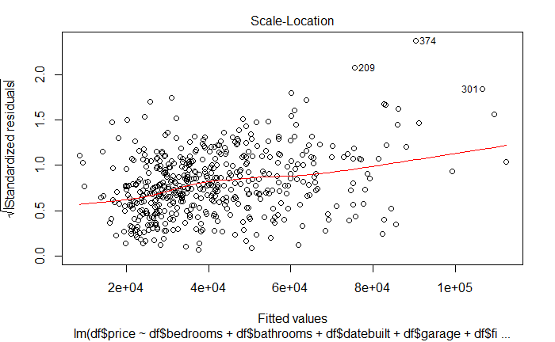

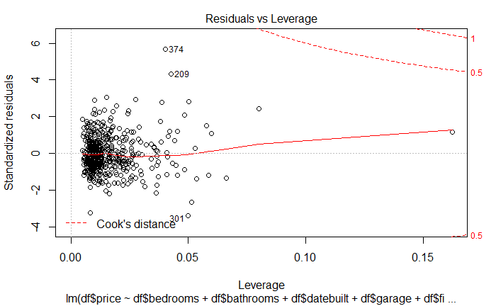

```r
plot(m)
```

### Question 2(b)

Attempt to improve the regression equation found in (a). Justify your decisions in constructing and carrying out the analysis.

```r
full.model <- lm(df$price ~ df$bedrooms + df$bathrooms + df$datebuilt + df$garage +df$fireplace + df$floorarea + df$detached)
reduced.model <- step(full.model, direction='backward')
```

```
Start:  AIC=9343.39
df$price ~ df$bedrooms + df$bathrooms + df$datebuilt + df$garage +
    df$fireplace + df$floorarea + df$detached

               Df  Sum of Sq        RSS    AIC
- df$bedrooms   1 1.1388e+08 6.5578e+10 9342.3
<none>                       6.5464e+10 9343.4
- df$bathrooms  1 3.9804e+08 6.5862e+10 9344.4
- df$fireplace  1 8.7433e+08 6.6339e+10 9348.0
- df$detached   1 4.2121e+09 6.9676e+10 9372.5
- df$datebuilt  1 7.1168e+09 7.2581e+10 9392.9
- df$garage     1 9.8904e+09 7.5355e+10 9411.6
- df$floorarea  1 3.7819e+10 1.0328e+11 9568.9

Step:  AIC=9342.26
df$price ~ df$bathrooms + df$datebuilt + df$garage + df$fireplace +
    df$floorarea + df$detached

               Df  Sum of Sq        RSS    AIC
<none>                       6.5578e+10 9342.3
- df$bathrooms  1 3.8265e+08 6.5961e+10 9343.2
- df$fireplace  1 8.6500e+08 6.6443e+10 9346.8
- df$detached   1 4.3063e+09 6.9884e+10 9372.0
- df$datebuilt  1 7.7124e+09 7.3290e+10 9395.7
- df$garage     1 1.0025e+10 7.5603e+10 9411.2
- df$floorarea  1 6.0089e+10 1.2567e+11 9664.8
```

```r
summary(reduced.model)$coefficients[,4]
```

```
 (Intercept) df$bathrooms df$datebuilt    df$garage df$fireplace df$floorarea  df$detached
1.485234e-13 9.083115e-02 1.440391e-13 6.179566e-17 1.115327e-02 1.693713e-71 2.257187e-08
```

```r
summary(m)$coefficients[,4]
```

```
 (Intercept)  df$bedrooms df$bathrooms df$datebuilt    df$garage df$fireplace df$floorarea  df$detached
8.498205e-13 3.558354e-01 8.464759e-02 1.121178e-12 9.773396e-17 1.074073e-02 1.438719e-50 3.193829e-08
```

```r
print('The P-value of bedrooms is larger than 0.05,So it is been romoved')
```

```
[1] "The P-value of bedrooms is larger than 0.05,So it is been romoved"
```

## Question 3

This is Exercise 11 in Chapter 9 of the Textbook [R].

### Question 3(a)

Using R and the [Milwaukee dataset](http://spatial.binghamton.edu/geog533/data/Milwaukee_Sales.csv) described in Section 1.9.2, construct a regression equation using housing sales price as the dependent variable, and number of bedrooms, lot size, finished square footage in the house, age of house, and number of bathrooms, as the independent variables. Investigate the importance of multicollinearity and outliers. Comment on the weaknesses of this specification, and on the results.

```r
url = "http://spatial.binghamton.edu/geog533/data/Milwaukee_Sales.csv"
df_new <- read.csv(url)
m_new <- lm(df_new$SalePrice ~ df_new$Bedrms + df_new$LotSize + df_new$FinSqft + df_new$Age + df_new$Baths)
a <- anova(m_new)
sst<- sum(a$`Sum Sq`)
r <- a$`Sum Sq`/sst
vif <- 1/(1-r)
rbind(row.names(a),round(vif,digits = 3))
```

```
     [,1]            [,2]             [,3]             [,4]         [,5]           [,6]
[1,] "df_new$Bedrms" "df_new$LotSize" "df_new$FinSqft" "df_new$Age" "df_new$Baths" "Residuals"
[2,] "1.085"         "1.047"          "1.53"           "1.003"      "1.014"        "2.055"
```

### Question 3(b)

Attempt to improve the regression equation found in (a). Justify your decisions in constructing and carrying out the analysis.

```r
full.model <- lm(df_new$SalePrice ~ df_new$Bedrms + df_new$LotSize + df_new$FinSqft + df_new$Age + df_new$Baths)
reduced.model <- step(full.model, direction='backward')
```

```
Start:  AIC=31937.3
df_new$SalePrice ~ df_new$Bedrms + df_new$LotSize + df_new$FinSqft +
    df_new$Age + df_new$Baths

                 Df  Sum of Sq        RSS   AIC
<none>                         5.3669e+12 31937
- df_new$Age      1 1.0901e+10 5.3778e+12 31938
- df_new$LotSize  1 1.1485e+11 5.4817e+12 31966
- df_new$Baths    1 1.4414e+11 5.5110e+12 31974
- df_new$Bedrms   1 5.4651e+11 5.9134e+12 32076
- df_new$FinSqft  1 1.8347e+12 7.2016e+12 32361
```

```r
summary(reduced.model)$coefficients[,4]
```

```
   (Intercept)  df_new$Bedrms df_new$LotSize df_new$FinSqft     df_new$Age   df_new$Baths
  5.405258e-03   2.823019e-32   3.263562e-08   3.020059e-94   8.710815e-02   6.285156e-10
```

```r
summary(m_new)$coefficients[,4]
```

```
   (Intercept)  df_new$Bedrms df_new$LotSize df_new$FinSqft     df_new$Age   df_new$Baths
  5.405258e-03   2.823019e-32   3.263562e-08   3.020059e-94   8.710815e-02   6.285156e-10
```

```r
print('no one been removed')
```

```
[1] "no one been removed"
```